# NDFS Synthesis Manuscript: Chlorophyll analysis

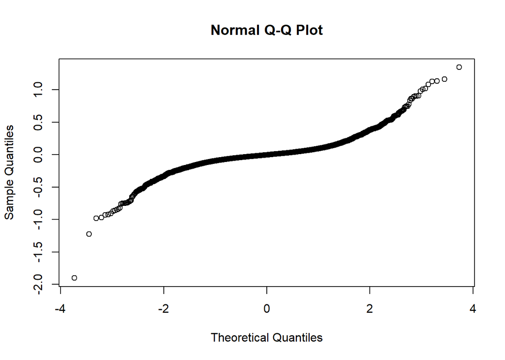

```r
qqnorm(resid_lmer_lag2b)
```

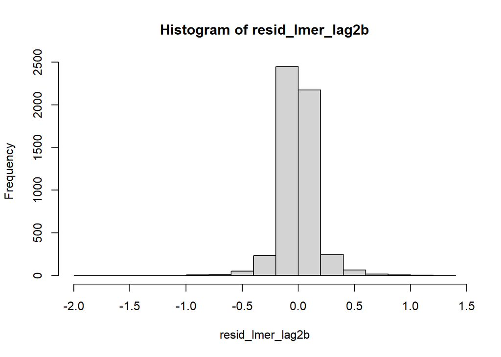

```r
hist(resid_lmer_lag2b)
```

The residuals still look a little strange. Let’s look at the ANOVA table.

```r
Anova(m_chla_lmer_lag2b, type = 3, contrasts=list(topic=contr.sum, sys=contr.sum))
```

```
## Analysis of Deviance Table (Type III Wald chisquare tests)
##
## Response: Chla_log
##                      Chisq Df Pr(>Chisq)
## (Intercept)       118.0011  1  < 2.2e-16 ***
## Year_fct           10.7569  6    0.09619 .
## Region             22.9914  1  1.627e-06 ***
## FlowActionPeriod    1.6245  2    0.44386
## lag1             5445.3569  1  < 2.2e-16 ***
## lag2               22.5668  1  2.030e-06 ***
## Year_fct:Region    15.9784  6    0.01387 *
## ---
## Signif. codes:  0 '***' 0.001 '**' 0.01 '*' 0.05 '.' 0.1 ' ' 1
```

Again, only the main effect of Region and the Year:Region interaction is significant in the model. Let’s take a closer look at the pairwise contrasts.

```r
# Contrasts in Region main effect
emmeans(m_chla_lmer_lag2b, specs = pairwise ~ Region, adjust = "sidak")
```

```
## $emmeans
##  Region     emmean       SE  df asymp.LCL asymp.UCL
##  Upstream    8.578 0.006888 Inf     8.564     8.591
##  Downstream  8.501 0.009378 Inf     8.483     8.520
##
## Results are averaged over the levels of: Year_fct, FlowActionPeriod
## Degrees-of-freedom method: asymptotic
## Confidence level used: 0.95
##
## $contrasts
##  contrast              estimate     SE  df z.ratio p.value
##  Upstream - Downstream   0.0763 0.0125 Inf   6.106  <.0001
##
## Results are averaged over the levels of: Year_fct, FlowActionPeriod
## Degrees-of-freedom method: asymptotic
```

```r
# Contrasts in Region for each Year
emmeans(m_chla_lmer_lag2b, specs = pairwise ~ Region | Year_fct, adjust = "sidak")
```

```
## $emmeans
## Year_fct = 2013:
##  Region     emmean       SE  df asymp.LCL asymp.UCL
##  Upstream    8.597 0.011271 Inf     8.574     8.619
##  Downstream  8.509 0.013320 Inf     8.483     8.535
##
## Year_fct = 2014:
##  Region     emmean       SE  df asymp.LCL asymp.UCL
##  Upstream    8.567 0.009797 Inf     8.548     8.586
##  Downstream  8.516 0.014116 Inf     8.488     8.543
##
## Year_fct = 2015:
##  Region     emmean       SE  df asymp.LCL asymp.UCL
##  Upstream    8.575 0.009419 Inf     8.557     8.594
##  Downstream  8.512 0.012431 Inf     8.488     8.537
##
## Year_fct = 2016:
##  Region     emmean       SE  df asymp.LCL asymp.UCL
##  Upstream    8.581 0.010120 Inf     8.561     8.601
##  Downstream  8.530 0.011969 Inf     8.506     8.553
##
## Year_fct = 2017:
##  Region     emmean       SE  df asymp.LCL asymp.UCL
##  Upstream    8.583 0.009805 Inf     8.564     8.602
##  Downstream  8.501 0.014036 Inf     8.473     8.528
##
## Year_fct = 2018:
##  Region     emmean       SE  df asymp.LCL asymp.UCL
##  Upstream    8.563 0.008986 Inf     8.546     8.581
##  Downstream  8.464 0.013714 Inf     8.437     8.491
##
## Year_fct = 2019:
##  Region     emmean       SE  df asymp.LCL asymp.UCL
##  Upstream    8.577 0.009150 Inf     8.559     8.595
##  Downstream  8.477 0.013622 Inf     8.451     8.504
##
## Results are averaged over the levels of: FlowActionPeriod
## Degrees-of-freedom method: asymptotic
## Confidence level used: 0.95
##
```

[output cut: 16 more lines]

```
##
## Year_fct = 2017:
##  contrast              estimate     SE  df z.ratio p.value
##  Upstream - Downstream   0.0823 0.0178 Inf   4.630  <.0001
##
## Year_fct = 2018:
##  contrast              estimate     SE  df z.ratio p.value
##  Upstream - Downstream   0.0994 0.0170 Inf   5.849  <.0001
##
## Year_fct = 2019:
##  contrast              estimate     SE  df z.ratio p.value
##  Upstream - Downstream   0.0999 0.0173 Inf   5.777  <.0001
##
## Results are averaged over the levels of: FlowActionPeriod
## Degrees-of-freedom method: asymptotic
```

```r
# Contrasts in Year for each Region
em_lmer_yr_reg <- emmeans(m_chla_lmer_lag2b, specs = pairwise ~ Year_fct | Region, adjust = "sidak")
multcomp::cld(em_lmer_yr_reg$emmeans, sort = FALSE, Letters = letters)
```

```
## Region = Upstream:
##  Year_fct emmean       SE  df asymp.LCL asymp.UCL .group
##  2013      8.597 0.011271 Inf     8.574     8.619  a
##  2014      8.567 0.009797 Inf     8.548     8.586  a
##  2015      8.575 0.009419 Inf     8.557     8.594  a
##  2016      8.581 0.010120 Inf     8.561     8.601  a
##  2017      8.583 0.009805 Inf     8.564     8.602  a
##  2018      8.563 0.008986 Inf     8.546     8.581  a
##  2019      8.577 0.009150 Inf     8.559     8.595  a
##
## Region = Downstream:
##  Year_fct emmean       SE  df asymp.LCL asymp.UCL .group
##  2013      8.509 0.013320 Inf     8.483     8.535  ab
##  2014      8.516 0.014116 Inf     8.488     8.543  ab
##  2015      8.512 0.012431 Inf     8.488     8.537  ab
##  2016      8.530 0.011969 Inf     8.506     8.553  a
##  2017      8.501 0.014036 Inf     8.473     8.528  abc
##  2018      8.464 0.013714 Inf     8.437     8.491    c
##  2019      8.477 0.013622 Inf     8.451     8.504   bc
##
## Results are averaged over the levels of: FlowActionPeriod
## Degrees-of-freedom method: asymptotic
## Confidence level used: 0.95
## P value adjustment: tukey method for comparing a family of 7 estimates
## significance level used: alpha = 0.05
## NOTE: If two or more means share the same grouping symbol,
##       then we cannot show them to be different.
##       But we also did not show them to be the same.
```

These results are very similar to the GAM model results. Like with the GAM model, upstream was always higher than downstream in all years, and none of the years differed significantly in the upstream region. In the downstream region, 2018 was lower than 2013-2016, and 2019 was lower than 2016.

# Re-run GAM at Station level

It’s encouraging that the GAM and LMER models had similar results. Unfortunately, neither found a significant effect of flow pulse period. Looking at the station level plots, it does appear that there is a chlorophyll response to flow pulse period at some of the stations. Let’s re-run the GAM model at the station level, including all stations at first. We’ll include all two-way interactions between Year, Flow Action Period, and Station and a smooth term for day of year to account for seasonality. We won’t account for serial autocorrelation in our initial GAM model.

## Initial Model

```r
m_chla_gam_st <- gam(
  Chla_log ~ (Year_fct + FlowActionPeriod + StationCode)^2 + s(DOY),
  data = df_chla_c,
  method = "REML"
)
```

Lets look at the model summary and diagnostics:

```r
summary(m_chla_gam_st)
```

```
##
## Family: gaussian
## Link function: identity
##
## Formula:
## Chla_log ~ (Year_fct + FlowActionPeriod + StationCode)^2 + s(DOY)
##
## Parametric coefficients:
##                                          Estimate Std. Error t value Pr(>|t|)
## (Intercept)                             8.9877125  0.0850465 105.680  < 2e-16
## Year_fct2014                           -0.0001447  0.0936376  -0.002 0.998767
## Year_fct2015                            0.0742784  0.0688351   1.079 0.280602
## Year_fct2016                           -0.0560153  0.0977430  -0.573 0.566610
## Year_fct2017                            0.4126917  0.0858876   4.805 1.59e-06
## Year_fct2018                            0.1086446  0.0851215   1.276 0.201889
## Year_fct2019                           -0.0116491  0.0853000  -0.137 0.891379
## FlowActionPeriodDuring                  0.0217904  0.0635643   0.343 0.731756
## FlowActionPeriodAfter                   0.8455015  0.0706154  11.973  < 2e-16
## StationCodeRD22                         0.7161405  0.0889423   8.052 9.98e-16
## StationCodeI80                          0.6259439  0.0678434   9.226  < 2e-16
## StationCodeLIS                         -0.0803806  0.0854926  -0.940 0.347155
## StationCodeSTTD                        -0.3913993  0.0903159  -4.334 1.49e-05
## StationCodeLIB                         -1.4277519  0.0853133 -16.735  < 2e-16
## StationCodeRYI                         -1.1252069  0.0864671 -13.013  < 2e-16
## StationCodeRVB                         -1.5884529  0.0843502 -18.832  < 2e-16
## Year_fct2014:FlowActionPeriodDuring    -0.0945012  0.0582321  -1.623 0.104683
## Year_fct2015:FlowActionPeriodDuring    -0.0823757  0.0517134  -1.593 0.111236
## Year_fct2016:FlowActionPeriodDuring    -0.2810510  0.0735623  -3.821 0.000135
## Year_fct2017:FlowActionPeriodDuring    -0.1481757  0.0563787  -2.628 0.008608
## Year_fct2018:FlowActionPeriodDuring    -0.0699917  0.0514125  -1.361 0.173452
## Year_fct2019:FlowActionPeriodDuring    -0.4655619  0.0523856  -8.887  < 2e-16
## Year_fct2014:FlowActionPeriodAfter     -0.4250913  0.0515033  -8.254  < 2e-16
## Year_fct2015:FlowActionPeriodAfter     -0.2401225  0.0514701  -4.665 3.16e-06
## Year_fct2016:FlowActionPeriodAfter     -0.4289829  0.0766805  -5.594 2.32e-08
## Year_fct2017:FlowActionPeriodAfter     -0.5399129  0.0512193 -10.541  < 2e-16
## Year_fct2018:FlowActionPeriodAfter     -0.4701620  0.0500465  -9.394  < 2e-16
## Year_fct2019:FlowActionPeriodAfter     -0.2172227  0.0499426  -4.349 1.39e-05
## Year_fct2014:StationCodeRD22           -0.5721979  0.1024033  -5.588 2.42e-08
## Year_fct2015:StationCodeRD22           -0.1463480  0.0760411  -1.925 0.054334
## Year_fct2016:StationCodeRD22           -0.4098169  0.0960924  -4.265 2.04e-05
```

[output cut: 135 more lines]

```
## FlowActionPeriodAfter:StationCodeRYI   ***
## FlowActionPeriodDuring:StationCodeRVB  **
## FlowActionPeriodAfter:StationCodeRVB   ***
## ---
## Signif. codes:  0 '***' 0.001 '**' 0.01 '*' 0.05 '.' 0.1 ' ' 1
##
## Approximate significance of smooth terms:
##          edf Ref.df     F p-value
## s(DOY) 8.005  8.725 19.31  <2e-16 ***
## ---
## Signif. codes:  0 '***' 0.001 '**' 0.01 '*' 0.05 '.' 0.1 ' ' 1
##
## Rank: 89/93
## R-sq.(adj) =  0.882   Deviance explained = 88.3%
## -REML = 2280.5  Scale est. = 0.1274    n = 5429
```

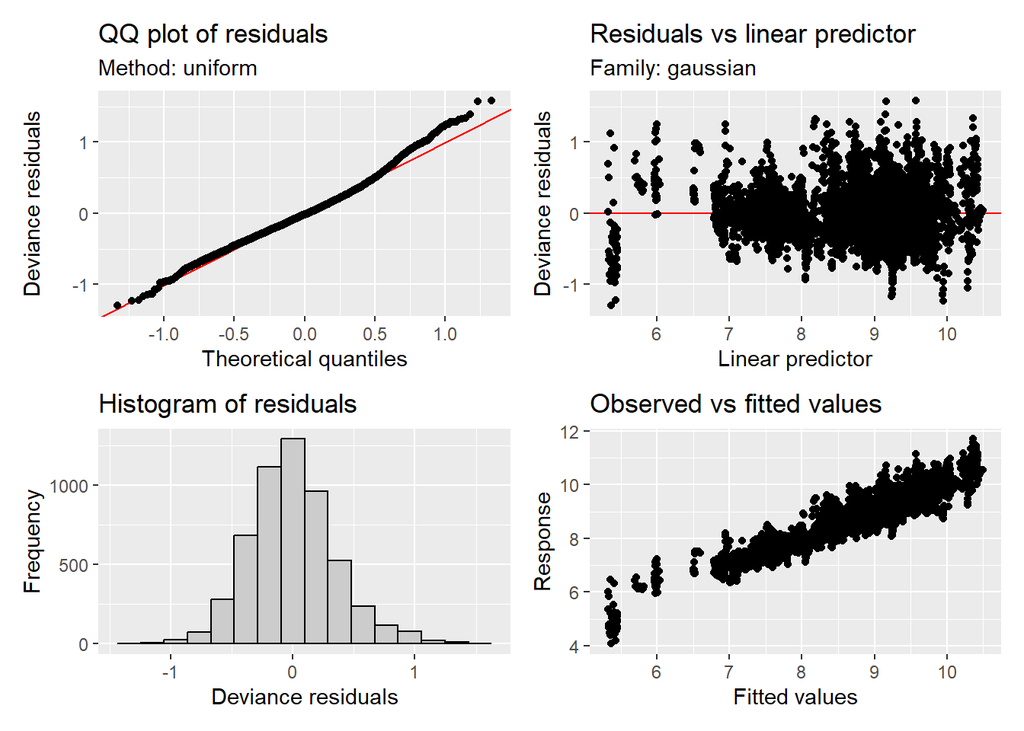

```r
appraise(m_chla_gam_st)
```

```r
k.check(m_chla_gam_st)
```

```
##        k'      edf   k-index p-value
## s(DOY)  9 8.005388 0.9563788       0
```

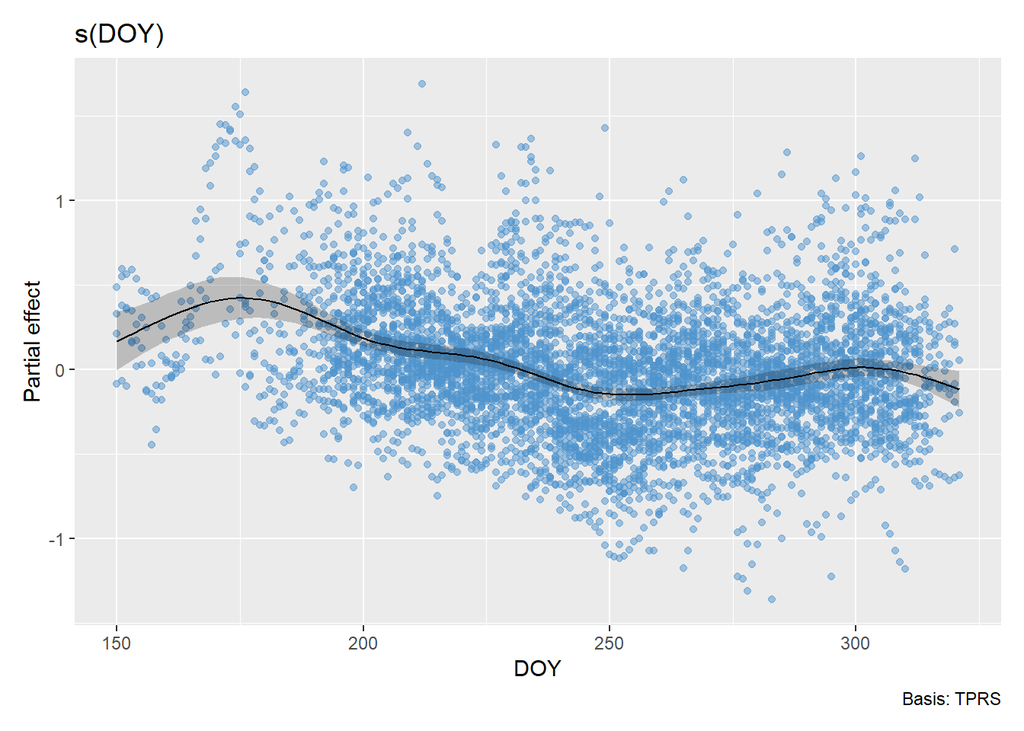

```r
draw(m_chla_gam_st, select = 1, residuals = TRUE, rug = FALSE)
```

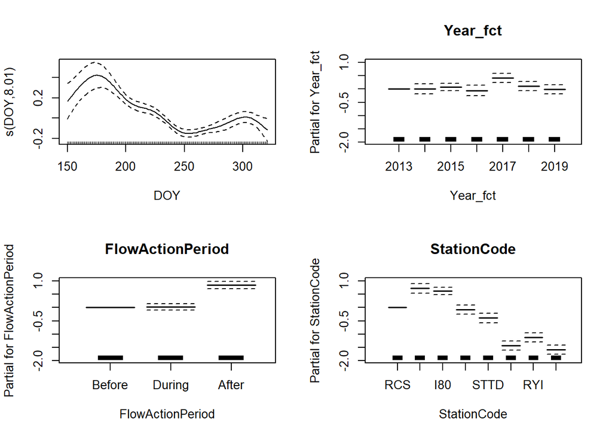

```r
plot(m_chla_gam_st, pages = 1, all.terms = TRUE)
```

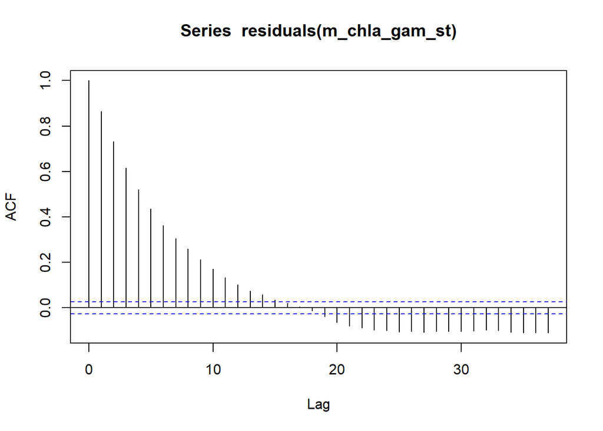

```r
acf(residuals(m_chla_gam_st))
```

```r
Box.test(residuals(m_chla_gam_st), lag = 20, type = 'Ljung-Box')
```

```
##
##  Box-Ljung test
##
## data:  residuals(m_chla_gam_st)
## X-squared = 13752, df = 20, p-value < 2.2e-16
```

## Model with k=5

Not surprisingly, the model definitely has residual autocorrelation as indicated by the ACF plot and the Box-Ljung test. The smooth term for day of year may also be overfitted as it was with the initial model using Regions. Again, let’s try a smaller k-value for the smooth first, then lets try to address the residual autocorrelation.

```r
m_chla_gam_st_k5 <- gam(
  Chla_log ~ (Year_fct + FlowActionPeriod + StationCode)^2 + s(DOY, k = 5),
  data = df_chla_c,
  method = "REML"
)

summary(m_chla_gam_st_k5)
```

```
##
## Family: gaussian
## Link function: identity
##
## Formula:
## Chla_log ~ (Year_fct + FlowActionPeriod + StationCode)^2 + s(DOY,
##     k = 5)
##
## Parametric coefficients:
##                                        Estimate Std. Error t value Pr(>|t|)
## (Intercept)                             8.68631    0.08372 103.760  < 2e-16 ***
## Year_fct2014                            0.29960    0.06777   4.421 1.00e-05 ***
## Year_fct2015                            0.39326    0.09804   4.011 6.13e-05 ***
## Year_fct2016                            0.35872    0.10005   3.585  0.00034 ***
## Year_fct2017                            0.71846    0.09040   7.947 2.31e-15 ***
## Year_fct2018                            0.41537    0.09021   4.605 4.23e-06 ***
## Year_fct2019                            0.29622    0.09031   3.280  0.00104 **
## FlowActionPeriodDuring                 -0.02294    0.06306  -0.364  0.71601
## FlowActionPeriodAfter                   0.82808    0.06895  12.010  < 2e-16 ***
## StationCodeRD22                         1.04110    0.08871  11.736  < 2e-16 ***
## StationCodeI80                          0.95049    0.08937  10.636  < 2e-16 ***
## StationCodeLIS                          0.23561    0.08493   2.774  0.00556 **
## StationCodeSTTD                        -0.06234    0.06350  -0.982  0.32627
## StationCodeLIB                         -1.11634    0.08459 -13.198  < 2e-16 ***
## StationCodeRYI                         -1.86375    0.05677 -32.829  < 2e-16 ***
## StationCodeRVB                         -1.27406    0.08377 -15.209  < 2e-16 ***
## Year_fct2014:FlowActionPeriodDuring    -0.08386    0.05800  -1.446  0.14829
## Year_fct2015:FlowActionPeriodDuring    -0.07698    0.05184  -1.485  0.13762
## Year_fct2016:FlowActionPeriodDuring    -0.36767    0.06662  -5.519 3.56e-08 ***
## Year_fct2017:FlowActionPeriodDuring    -0.14640    0.05623  -2.603  0.00926 **
## Year_fct2018:FlowActionPeriodDuring    -0.06467    0.05144  -1.257  0.20877
## Year_fct2019:FlowActionPeriodDuring    -0.46214    0.05234  -8.830  < 2e-16 ***
## Year_fct2014:FlowActionPeriodAfter     -0.40263    0.05127  -7.853 4.89e-15 ***
## Year_fct2015:FlowActionPeriodAfter     -0.23648    0.05160  -4.583 4.69e-06 ***
## Year_fct2016:FlowActionPeriodAfter     -0.53143    0.07046  -7.542 5.40e-14 ***
## Year_fct2017:FlowActionPeriodAfter     -0.52391    0.05092 -10.288  < 2e-16 ***
## Year_fct2018:FlowActionPeriodAfter     -0.45572    0.05005  -9.105  < 2e-16 ***
## Year_fct2019:FlowActionPeriodAfter     -0.20050    0.04982  -4.025 5.78e-05 ***
## Year_fct2014:StationCodeRD22           -0.89755    0.07853 -11.429  < 2e-16 ***
## Year_fct2015:StationCodeRD22           -0.47440    0.10258  -4.625 3.84e-06 ***
```

[output cut: 51 more lines]

```
## FlowActionPeriodAfter:StationCodeRYI   -0.54180    0.05846  -9.268  < 2e-16 ***
## FlowActionPeriodDuring:StationCodeRVB   0.15774    0.05339   2.954  0.00315 **
## FlowActionPeriodAfter:StationCodeRVB   -0.66458    0.04793 -13.867  < 2e-16 ***
## ---
## Signif. codes:  0 '***' 0.001 '**' 0.01 '*' 0.05 '.' 0.1 ' ' 1
##
## Approximate significance of smooth terms:
##          edf Ref.df     F p-value
## s(DOY) 3.876  3.992 34.17  <2e-16 ***
## ---
## Signif. codes:  0 '***' 0.001 '**' 0.01 '*' 0.05 '.' 0.1 ' ' 1
##
## Rank: 84/88
## R-sq.(adj) =  0.881   Deviance explained = 88.3%
## -REML = 2290.6  Scale est. = 0.12822   n = 5429
```

```r
k.check(m_chla_gam_st_k5)
```

```
##        k'      edf  k-index p-value
## s(DOY)  4 3.876466 1.005801  0.6325
```

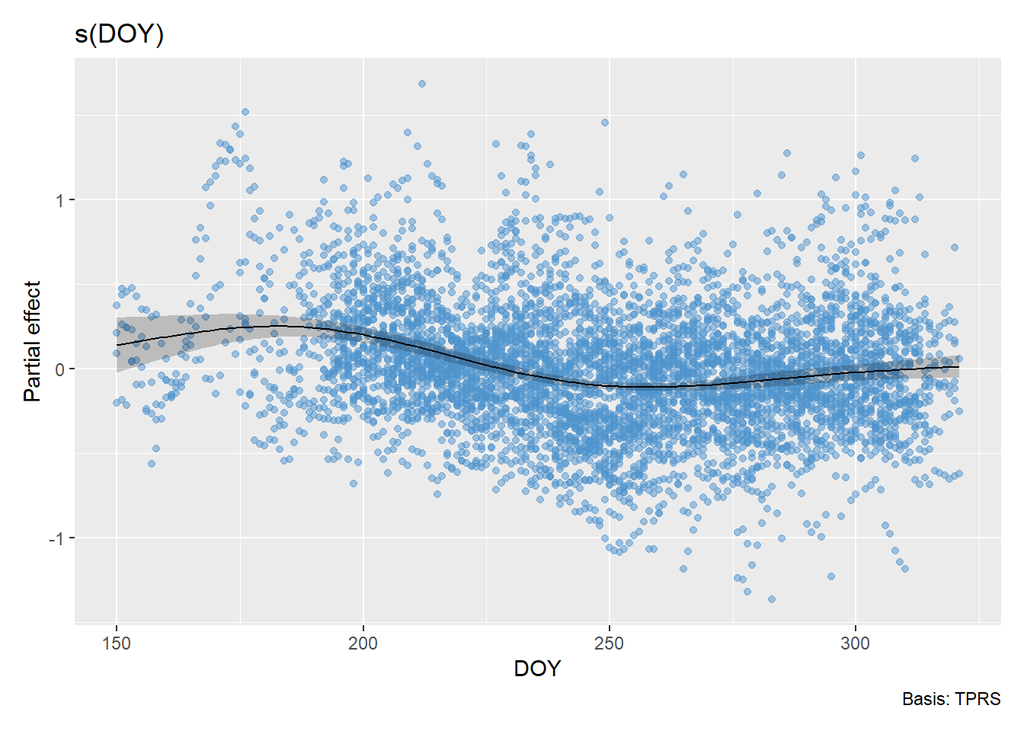

```r
draw(m_chla_gam_st_k5, select = 1, residuals = TRUE, rug = FALSE)
```

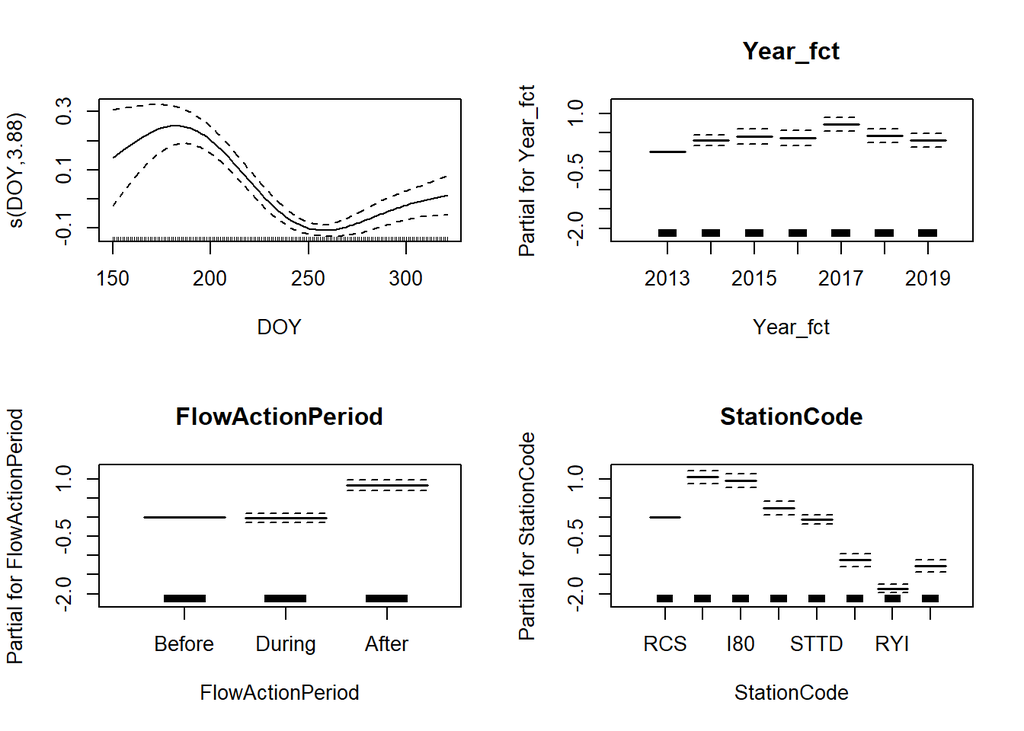

```r
plot(m_chla_gam_st_k5, pages = 1, all.terms = TRUE)
```

Changing the k-value to 5 seems to help reduce the “wiggliness” of the smooth term for DOY. Now, let’s use an AR(p) model to account for the correlated residuals. We’ll run AR(1), AR(2), AR(3), and AR(4) models and compare them using AIC. The `nlme` model engine that underlies the `gamm()` function produces an error when there are empty station-year-action period combinations in the data set, so for now we’ll remove the two stations (RCS and RYI) that are missing data for a few years.

## Model with AR() correlation structure

```r
# Define model formula as an object
f_chla_gam_st_k5 <- as.formula("Chla_log ~ (Year_fct + FlowActionPeriod + StationCode)^2 + s(DOY, k = 5)")

# Remove RCS and RYI from the data set
df_chla_c2 <- df_chla_c %>% filter(!StationCode %in% c("RCS", "RYI"))

# Fit original model with k = 5 and four successive AR(p) models
m_chla_gamm_st_k5 <- gamm(
  f_chla_gam_st_k5,
  data = df_chla_c2,
  method = "REML"
)

m_chla_gamm_st_k5_ar1 <- gamm(
  f_chla_gam_st_k5,
  data = df_chla_c2,
  correlation = corARMA(form = ~ 1|Year_fct, p = 1), # grouped by Year_fct
  method = "REML"
)

m_chla_gamm_st_k5_ar2 <- gamm(
  f_chla_gam_st_k5,
  data = df_chla_c2,
  correlation = corARMA(form = ~ 1|Year_fct, p = 2),
  method = "REML"
)

m_chla_gamm_st_k5_ar3 <- gamm(
  f_chla_gam_st_k5,
  data = df_chla_c2,
  correlation = corARMA(form = ~ 1|Year_fct, p = 3),
  method = "REML"
)

m_chla_gamm_st_k5_ar4 <- gamm(
  f_chla_gam_st_k5,
  data = df_chla_c2,
  correlation = corARMA(form = ~ 1|Year_fct, p = 4),
  method = "REML"
)

# Compare models
anova(
  m_chla_gamm_st_k5$lme,
  m_chla_gamm_st_k5_ar1$lme,
  m_chla_gamm_st_k5_ar2$lme,
  m_chla_gamm_st_k5_ar3$lme,
  m_chla_gamm_st_k5_ar4$lme
)
```

```
##                           Model df       AIC       BIC    logLik   Test
## m_chla_gamm_st_k5$lme         1 69  3848.889  4289.535 -1855.445
## m_chla_gamm_st_k5_ar1$lme     2 70 -2970.642 -2523.610  1555.321 1 vs 2
## m_chla_gamm_st_k5_ar2$lme     3 71 -2984.225 -2530.807  1563.113 2 vs 3
## m_chla_gamm_st_k5_ar3$lme     4 72 -2986.140 -2526.336  1565.070 3 vs 4
## m_chla_gamm_st_k5_ar4$lme     5 73 -2990.612 -2524.421  1568.306 4 vs 5
##                            L.Ratio p-value
## m_chla_gamm_st_k5$lme
## m_chla_gamm_st_k5_ar1$lme 6821.532  <.0001
## m_chla_gamm_st_k5_ar2$lme   15.583  0.0001
## m_chla_gamm_st_k5_ar3$lme    3.915  0.0479
## m_chla_gamm_st_k5_ar4$lme    6.471  0.0110
```

It looks like the AR(4) model has the best fit according to the AIC values. However, the AR(2) model is best according to the BIC values. Since AIC tends to pick more complex models than BIC, let’s choose the AR(2) model and take a closer look at that one.

## AR(2) Model

```r
# Pull out the residuals and the GAM model
resid_st_ar2 <- residuals(m_chla_gamm_st_k5_ar2$lme, type = "normalized")
m_chla_gamm_st_k5_ar2_gam <- m_chla_gamm_st_k5_ar2$gam

summary(m_chla_gamm_st_k5_ar2_gam)
```

```
##
## Family: gaussian
## Link function: identity
##
## Formula:
## Chla_log ~ (Year_fct + FlowActionPeriod + StationCode)^2 + s(DOY,
##     k = 5)
##
## Parametric coefficients:
##                                         Estimate Std. Error t value Pr(>|t|)
## (Intercept)                             9.543052   0.181283  52.642  < 2e-16
## Year_fct2014                            0.023001   0.238494   0.096 0.923173
## Year_fct2015                           -0.143971   0.235386  -0.612 0.540809
## Year_fct2016                           -0.878058   0.254099  -3.456 0.000554
## Year_fct2017                           -0.301980   0.238890  -1.264 0.206264
## Year_fct2018                           -0.022575   0.235242  -0.096 0.923552
## Year_fct2019                            0.289060   0.237351   1.218 0.223344
## FlowActionPeriodDuring                  0.007088   0.083545   0.085 0.932391
## FlowActionPeriodAfter                   0.214046   0.107352   1.994 0.046227
## StationCodeI80                          0.346569   0.269398   1.286 0.198352
## StationCodeLIS                         -0.515793   0.170289  -3.029 0.002469
## StationCodeSTTD                        -0.410490   0.229645  -1.787 0.073926
## StationCodeLIB                         -2.127402   0.217168  -9.796  < 2e-16
## StationCodeRVB                         -2.032855   0.169858 -11.968  < 2e-16
## Year_fct2014:FlowActionPeriodDuring    -0.088494   0.085508  -1.035 0.300765
## Year_fct2015:FlowActionPeriodDuring    -0.033589   0.085323  -0.394 0.693841
## Year_fct2016:FlowActionPeriodDuring    -0.119400   0.091186  -1.309 0.190465
## Year_fct2017:FlowActionPeriodDuring    -0.020808   0.085956  -0.242 0.808729
## Year_fct2018:FlowActionPeriodDuring    -0.198609   0.085245  -2.330 0.019858
## Year_fct2019:FlowActionPeriodDuring     0.074944   0.085849   0.873 0.382723
## Year_fct2014:FlowActionPeriodAfter     -0.262518   0.099492  -2.639 0.008355
## Year_fct2015:FlowActionPeriodAfter     -0.098981   0.099156  -0.998 0.318219
## Year_fct2016:FlowActionPeriodAfter     -0.250797   0.118315  -2.120 0.034084
## Year_fct2017:FlowActionPeriodAfter     -0.283734   0.101472  -2.796 0.005193
## Year_fct2018:FlowActionPeriodAfter     -0.321220   0.099345  -3.233 0.001232
## Year_fct2019:FlowActionPeriodAfter      0.095366   0.099778   0.956 0.339235
## Year_fct2014:StationCodeI80            -0.578816   0.346381  -1.671 0.094785
## Year_fct2015:StationCodeI80            -0.001156   0.346479  -0.003 0.997338
## Year_fct2016:StationCodeI80             0.746313   0.366019   2.039 0.041510
## Year_fct2017:StationCodeI80             0.352251   0.346105   1.018 0.308849
```

[output cut: 99 more lines]

```
## FlowActionPeriodDuring:StationCodeLIB
## FlowActionPeriodAfter:StationCodeLIB
## FlowActionPeriodDuring:StationCodeRVB
## FlowActionPeriodAfter:StationCodeRVB
## ---
## Signif. codes:  0 '***' 0.001 '**' 0.01 '*' 0.05 '.' 0.1 ' ' 1
##
## Approximate significance of smooth terms:
##          edf Ref.df     F p-value
## s(DOY) 2.633  2.633 19.05  <2e-16 ***
## ---
## Signif. codes:  0 '***' 0.001 '**' 0.01 '*' 0.05 '.' 0.1 ' ' 1
##
## R-sq.(adj) =   0.77
##   Scale est. = 0.28473   n = 4453
```

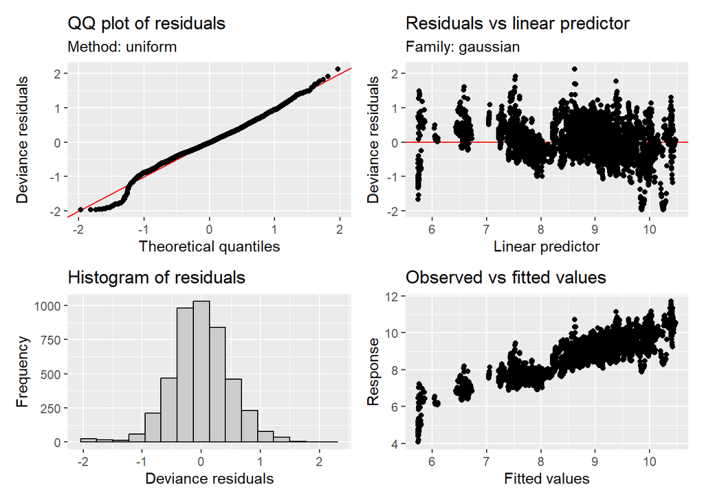

```r
appraise(m_chla_gamm_st_k5_ar2_gam)
```

```r
k.check(m_chla_gamm_st_k5_ar2_gam)
```

```
##        k'     edf   k-index p-value
## s(DOY)  4 2.63297 0.8606074       0
```

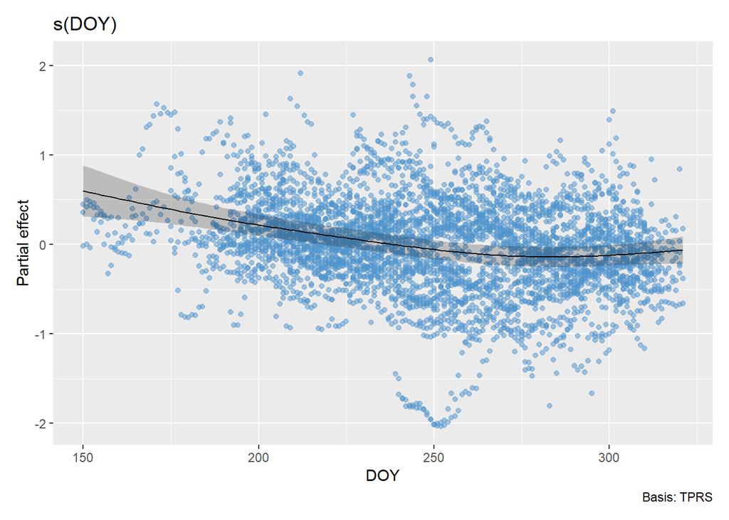

```r
draw(m_chla_gamm_st_k5_ar2_gam, select = 1, residuals = TRUE, rug = FALSE)
```

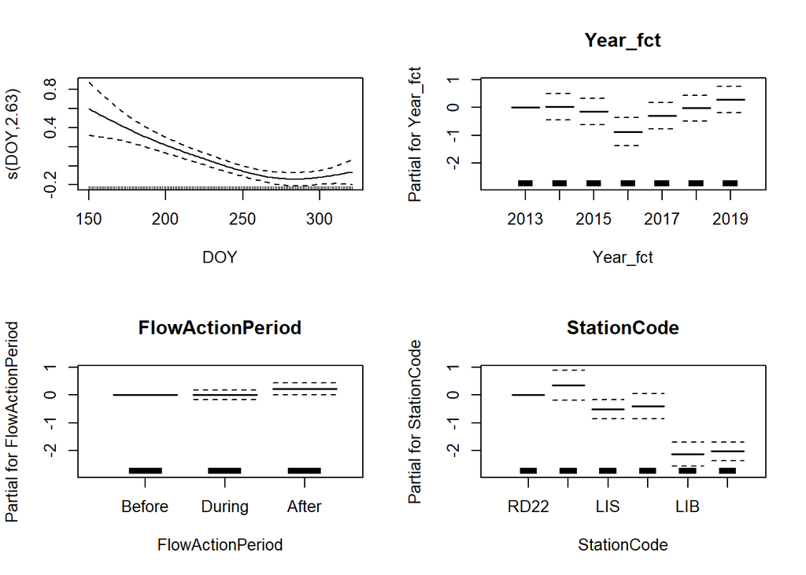

```r
plot(m_chla_gamm_st_k5_ar2_gam, pages = 1, all.terms = TRUE)
```

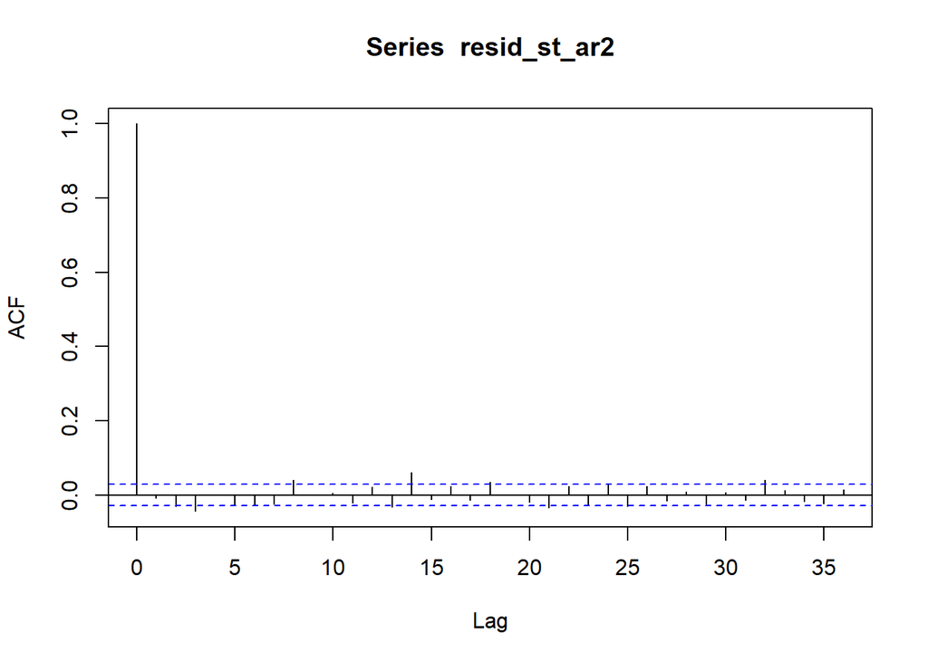

```r
acf(resid_st_ar2)
```

```r
Box.test(resid_st_ar2, lag = 20, type = 'Ljung-Box')
```

```
##
##  Box-Ljung test
##
## data:  resid_st_ar2
## X-squared = 64.149, df = 20, p-value = 1.594e-06
```

The AR(2) model has much less residual autocorrelation, and the diagnostics plots look pretty good. For some reason the p-value for the `k.check` is zero which may indicate that `k = 5` is too low. I may have to look into this further.

What does the ANOVA table look like for the AR(2) model?

```r
# the anova.gam function is similar to a type 3 ANOVA
anova(m_chla_gamm_st_k5_ar2_gam)
```

```
##
## Family: gaussian
## Link function: identity
##
## Formula:
## Chla_log ~ (Year_fct + FlowActionPeriod + StationCode)^2 + s(DOY,
##     k = 5)
##
## Parametric Terms:
##                              df      F  p-value
## Year_fct                      6  4.464 0.000164
## FlowActionPeriod              2  3.211 0.040408
## StationCode                   5 87.468  < 2e-16
## Year_fct:FlowActionPeriod    12  3.113 0.000204
## Year_fct:StationCode         30 21.176  < 2e-16
## FlowActionPeriod:StationCode 10  4.392 3.67e-06
##
## Approximate significance of smooth terms:
##          edf Ref.df     F p-value
## s(DOY) 2.633  2.633 19.05  <2e-16
```

All the interaction terms are significant in the AR(2) model. Let’s take a closer look at the pairwise contrasts.

### Pairwise contrasts

```r
# Contrasts in FlowActionPeriod for each Year
emmeans(
  m_chla_gamm_st_k5_ar2,
  data = df_chla_c2,
  specs = pairwise ~ FlowActionPeriod | Year_fct
)
```

```
## $emmeans
## Year_fct = 2013:
##  FlowActionPeriod emmean    SE   df lower.CL upper.CL
##  Before             8.70 0.132 4384     8.44     8.96
##  During             8.75 0.128 4384     8.50     9.00
##  After              8.86 0.132 4384     8.60     9.12
##
## Year_fct = 2014:
##  FlowActionPeriod emmean    SE   df lower.CL upper.CL
##  Before             8.66 0.128 4384     8.41     8.91
##  During             8.63 0.131 4384     8.37     8.88
##  After              8.56 0.132 4384     8.30     8.82
##
## Year_fct = 2015:
##  FlowActionPeriod emmean    SE   df lower.CL upper.CL
##  Before             8.59 0.126 4384     8.34     8.84
##  During             8.61 0.122 4384     8.37     8.85
##  After              8.65 0.125 4384     8.40     8.89
##
## Year_fct = 2016:
##  FlowActionPeriod emmean    SE   df lower.CL upper.CL
##  Before             8.81 0.150 4384     8.52     9.11
##  During             8.75 0.140 4384     8.47     9.02
##  After              8.72 0.133 4384     8.46     8.98
##
## Year_fct = 2017:
##  FlowActionPeriod emmean    SE   df lower.CL upper.CL
##  Before             8.59 0.130 4384     8.33     8.84
##  During             8.62 0.133 4384     8.36     8.88
##  After              8.46 0.134 4384     8.20     8.72
##
## Year_fct = 2018:
##  FlowActionPeriod emmean    SE   df lower.CL upper.CL
##  Before             8.08 0.126 4384     7.83     8.32
##  During             7.93 0.126 4384     7.69     8.18
##  After              7.92 0.128 4384     7.66     8.17
##
## Year_fct = 2019:
##  FlowActionPeriod emmean    SE   df lower.CL upper.CL
##  Before             8.15 0.129 4384     7.90     8.41
```

[output cut: 36 more lines]

```
##
## Year_fct = 2018:
##  contrast        estimate     SE   df t.ratio p.value
##  Before - During   0.1445 0.0618 4384   2.337  0.0509
##  Before - After    0.1630 0.0757 4384   2.154  0.0794
##  During - After    0.0185 0.0620 4384   0.298  0.9522
##
## Year_fct = 2019:
##  contrast        estimate     SE   df t.ratio p.value
##  Before - During  -0.1291 0.0629 4384  -2.053  0.0999
##  Before - After   -0.2536 0.0757 4384  -3.349  0.0024
##  During - After   -0.1245 0.0616 4384  -2.023  0.1067
##
## Results are averaged over the levels of: StationCode
## P value adjustment: tukey method for comparing a family of 3 estimates
```

```r
# Contrasts in FlowActionPeriod for each Station
emmeans(
  m_chla_gamm_st_k5_ar2,
  data = df_chla_c2,
  specs = pairwise ~ FlowActionPeriod | StationCode
)
```

```
## $emmeans
## StationCode = RD22:
##  FlowActionPeriod emmean     SE   df lower.CL upper.CL
##  Before             9.34 0.0861 4384     9.17     9.51
##  During             9.29 0.0840 4384     9.13     9.46
##  After              9.40 0.0840 4384     9.23     9.56
##
## StationCode = I80:
##  FlowActionPeriod emmean     SE   df lower.CL upper.CL
##  Before             9.65 0.1082 4384     9.44     9.86
##  During             9.62 0.1006 4384     9.43     9.82
##  After              9.72 0.0982 4384     9.52     9.91
##
## StationCode = LIS:
##  FlowActionPeriod emmean     SE   df lower.CL upper.CL
##  Before             8.81 0.0859 4384     8.65     8.98
##  During             8.78 0.0848 4384     8.61     8.95
##  After              8.87 0.0863 4384     8.70     9.04
##
## StationCode = STTD:
##  FlowActionPeriod emmean     SE   df lower.CL upper.CL
##  Before             8.42 0.0998 4384     8.23     8.62
##  During             8.55 0.1023 4384     8.35     8.75
##  After              8.19 0.1085 4384     7.98     8.41
##
## StationCode = LIB:
##  FlowActionPeriod emmean     SE   df lower.CL upper.CL
##  Before             7.31 0.0882 4384     7.13     7.48
##  During             7.28 0.0859 4384     7.11     7.45
##  After              7.31 0.0872 4384     7.14     7.48
##
## StationCode = RVB:
##  FlowActionPeriod emmean     SE   df lower.CL upper.CL
##  Before             7.54 0.0905 4384     7.36     7.71
##  During             7.54 0.0886 4384     7.37     7.71
##  After              7.57 0.0891 4384     7.40     7.75
##
## Results are averaged over the levels of: Year_fct
## Confidence level used: 0.95
##
```

[output cut: 24 more lines]

```
##
## StationCode = LIB:
##  contrast         estimate     SE   df t.ratio p.value
##  Before - During  0.029706 0.0626 4384   0.474  0.8833
##  Before - After  -0.000682 0.0846 4384  -0.008  1.0000
##  During - After  -0.030389 0.0617 4384  -0.493  0.8747
##
## StationCode = RVB:
##  contrast         estimate     SE   df t.ratio p.value
##  Before - During -0.003682 0.0617 4384  -0.060  0.9980
##  Before - After  -0.038808 0.0835 4384  -0.465  0.8879
##  During - After  -0.035126 0.0615 4384  -0.571  0.8357
##
## Results are averaged over the levels of: Year_fct
## P value adjustment: tukey method for comparing a family of 3 estimates
```

```r
# Contrasts in Station for each Year
multcomp::cld(
  emmeans(
    m_chla_gamm_st_k5_ar2,
    data = df_chla_c2,
    specs = pairwise ~ StationCode | Year_fct
  )$emmeans,
  sort = FALSE,
  Letters = letters
)
```

```
## Year_fct = 2013:
##  StationCode emmean    SE   df lower.CL upper.CL .group
##  RD22          9.56 0.172 4384     9.23     9.90  a
##  I80           9.92 0.226 4384     9.48    10.36  a
##  LIS           9.05 0.173 4384     8.71     9.39   b
##  STTD          9.12 0.217 4384     8.69     9.54  ab
##  LIB           7.42 0.182 4384     7.07     7.78    c
##  RVB           7.54 0.178 4384     7.19     7.89    c
##
## Year_fct = 2014:
##  StationCode emmean    SE   df lower.CL upper.CL .group
##  RD22          9.47 0.170 4384     9.14     9.80  a
##  I80           9.25 0.215 4384     8.83     9.67  ab
##  LIS           8.73 0.169 4384     8.40     9.06   b
##  STTD          8.81 0.220 4384     8.37     9.24   b
##  LIB           7.67 0.180 4384     7.32     8.03    c
##  RVB           7.77 0.182 4384     7.41     8.12    c
##
## Year_fct = 2015:
##  StationCode emmean    SE   df lower.CL upper.CL .group
##  RD22          9.37 0.163 4384     9.06     9.69  a
##  I80           9.73 0.219 4384     9.30    10.16  a
##  LIS           8.38 0.163 4384     8.06     8.70   bc
##  STTD          8.46 0.203 4384     8.06     8.86   b d
##  LIB           7.79 0.175 4384     7.45     8.13     de
##  RVB           7.96 0.171 4384     7.62     8.29    c e
##
## Year_fct = 2016:
##  StationCode emmean    SE   df lower.CL upper.CL .group
##  RD22          8.56 0.181 4384     8.21     8.92  ab
##  I80           9.67 0.231 4384     9.21    10.12    c
##  LIS           8.94 0.177 4384     8.60     9.29  a
##  STTD          9.17 0.242 4384     8.69     9.64  abc
##  LIB           8.42 0.182 4384     8.07     8.78   b d
##  RVB           7.81 0.205 4384     7.40     8.21     d
##
## Year_fct = 2017:
##  StationCode emmean    SE   df lower.CL upper.CL .group
##  RD22          9.16 0.170 4384     8.83     9.49  a
##  I80           9.87 0.208 4384     9.46    10.28   b
```

[output cut: 15 more lines]

```
##  StationCode emmean    SE   df lower.CL upper.CL .group
##  RD22          9.91 0.165 4384     9.58    10.23  a
##  I80          10.30 0.211 4384     9.88    10.71  a
##  LIS           9.01 0.168 4384     8.68     9.34   b
##  STTD          7.41 0.208 4384     7.00     7.81    c
##  LIB           6.51 0.185 4384     6.15     6.87     d
##  RVB           6.55 0.175 4384     6.21     6.90     d
##
## Results are averaged over the levels of: FlowActionPeriod
## Confidence level used: 0.95
## P value adjustment: tukey method for comparing a family of 6 estimates
## significance level used: alpha = 0.05
## NOTE: If two or more means share the same grouping symbol,
##       then we cannot show them to be different.
##       But we also did not show them to be the same.
```

```r
# Contrasts in Year for each Station
multcomp::cld(
  emmeans(
    m_chla_gamm_st_k5_ar2,
    data = df_chla_c2,
    specs = pairwise ~ Year_fct | StationCode
  )$emmeans,
  sort = FALSE,
  Letters = letters
)
```

```
## StationCode = RD22:
##  Year_fct emmean    SE   df lower.CL upper.CL .group
##  2013       9.56 0.172 4384     9.23     9.90  ab
##  2014       9.47 0.170 4384     9.14     9.80  ab
##  2015       9.37 0.163 4384     9.06     9.69  ab
##  2016       8.56 0.181 4384     8.21     8.92    c
##  2017       9.16 0.170 4384     8.83     9.49  a c
##  2018       9.37 0.164 4384     9.05     9.69  ab
##  2019       9.91 0.165 4384     9.58    10.23   b
##
## StationCode = I80:
##  Year_fct emmean    SE   df lower.CL upper.CL .group
##  2013       9.92 0.226 4384     9.48    10.36  ab
##  2014       9.25 0.215 4384     8.83     9.67  a c
##  2015       9.73 0.219 4384     9.30    10.16  abc
##  2016       9.67 0.231 4384     9.21    10.12  abc
##  2017       9.87 0.208 4384     9.46    10.28  ab
##  2018       8.90 0.212 4384     8.49     9.32    c
##  2019      10.30 0.211 4384     9.88    10.71   b
##
## StationCode = LIS:
##  Year_fct emmean    SE   df lower.CL upper.CL .group
##  2013       9.05 0.173 4384     8.71     9.39  a
##  2014       8.73 0.169 4384     8.40     9.06  ab
##  2015       8.38 0.163 4384     8.06     8.70   b
##  2016       8.94 0.177 4384     8.60     9.29  ab
##  2017       8.83 0.169 4384     8.50     9.16  ab
##  2018       8.81 0.164 4384     8.48     9.13  ab
##  2019       9.01 0.168 4384     8.68     9.34  ab
##
## StationCode = STTD:
##  Year_fct emmean    SE   df lower.CL upper.CL .group
##  2013       9.12 0.217 4384     8.69     9.54  a
##  2014       8.81 0.220 4384     8.37     9.24  a
##  2015       8.46 0.203 4384     8.06     8.86  a
##  2016       9.17 0.242 4384     8.69     9.64  a
##  2017       8.39 0.244 4384     7.91     8.87  a
##  2018       7.38 0.220 4384     6.95     7.81   b
##  2019       7.41 0.208 4384     7.00     7.81   b
##
```

[output cut: 12 more lines]

```
##  2013       7.54 0.178 4384     7.19     7.89  a
##  2014       7.77 0.182 4384     7.41     8.12  a
##  2015       7.96 0.171 4384     7.62     8.29  a
##  2016       7.81 0.205 4384     7.40     8.21  a
##  2017       7.70 0.188 4384     7.33     8.07  a
##  2018       7.52 0.176 4384     7.18     7.87  a
##  2019       6.55 0.175 4384     6.21     6.90   b
##
## Results are averaged over the levels of: FlowActionPeriod
## Confidence level used: 0.95
## P value adjustment: tukey method for comparing a family of 7 estimates
## significance level used: alpha = 0.05
## NOTE: If two or more means share the same grouping symbol,
##       then we cannot show them to be different.
##       But we also did not show them to be the same.
```

The differences between flow pulse periods were not significant in most years except During was higher than After in 2017 and After was higher than Before in 2019. Before was marginally higher than both During and After in 2018.

Similarly, the differences between flow pulse periods were not significant at most stations except After was lower than both Before and During at STTD.

Comparing Stations in each Year, there was an obvious gradient from the upstream to downstream stations with the highest chlorophyll values at the most upstream stations in the Toe Drain and the lowest values at the downstream stations across all years.